# Pathway analysis - Plots

Prime-seq analysis

Data analysis: Paulo Jannig | Karolinska Institutet

Last update: September 09, 2025

```r
print(setwd(dirname(rstudioapi::getSourceEditorContext()$path)))
```

```
#> [1] "/Users/paulo.jannig/Library/CloudStorage/OneDrive-KarolinskaInstitutet/Deng lab/Manuscripts_DengLab/CVD paper/zenodo_deposit/Zhao_et_al_2025_AortaSTZoffspring/scripts"
```

```r
# define variables ==========================================
filename_prefix <- "" # leave empty if not necessary
species <- "mouse" # mouse, human, pig, rat
ensembl_version <- 102 # define ensembl release version

file_formats <- list(
  #"png",
  "pdf"
)

# load libraries
required_Packages_Install <- c("tidyverse",
                               "msigdbr",
                               "clusterProfiler",
                               "org.Mm.eg.db",
                               "pheatmap",
                               "ggtext",
                               "RColorBrewer",
                               "scico",
                               "writexl",
                               "ggrepel",
                               "ggvenn",
                               "viridis",
                               "scales"
                               )

for(Package in required_Packages_Install){
  if(!require(Package,character.only = TRUE)) {
    BiocManager::install(Package, dependencies=TRUE)
  }
  library(Package,character.only = TRUE)
}

# source custom functions
source("load_functions.R") # source custom functions
```

# 1 Import data

Load pathways names replacements file

```r
pathways_replace <- read.delim(
  file = paste0("../05.miscellaneous/pathways_names_replacements.txt"),
  sep = "", header = T
)
replacements <- c(pathways_replace$replacement)
names(replacements) <- c(pathways_replace$original)
```

## 1.1 Metadata

```r
metadata <- readRDS("../01.metadata/metadata.Rds")
colnames(metadata)
```

```
#> [1] "Sample" "Group"  "Oligo"
```

```r
metadata$Sample
```

```
#>  [1] "M3-1" "M4-3" "M3-2" "M5-1" "M4-2" "M2-1" "M6-3" "M1-1" "M6-1" "M7-1"
#> [11] "M7-2"
```

```r
unique(metadata$Group)
```

```
#> [1] Control STZ
#> Levels: Control STZ
```

## 1.2 Hallmark

# 2 Contrasts

```r
group1 <- levels(metadata$Group)[2]
group_ref <- levels(metadata$Group)[1]


contrast1_name <- paste0(group1,"_vs_",group_ref)
contrast1_name
```

```
#> [1] "STZ_vs_Control"
```

```r
contrast1 <- readRDS(paste0("../02.results/pathways/pathways_GSEA_Hallmark_", contrast1_name, ".RDS"))
# contrast2 <- readRDS(paste0("../02.results/pathways/pathways_GSEA_Hallmark_", group2,"_vs_",group_ref,".RDS"))


contrasts <- set_names(
  list(contrast1),
  contrast1_name
)

# contrasts <- set_names(list(contrast1, contrast2),
#                        paste0(group1,"_vs_",group_ref),
#                        paste0(group2,"_vs_2",group_ref))
```

```r
gsea <- contrast1 %>%
  mutate(ID = stringr::str_replace_all(ID, "_", " ")) %>%
  mutate(ID = tools::toTitleCase(tolower(ID))) %>%
  mutate(ID = str_replace_all(ID, pattern = replacements)) %>%
  mutate(ID = stringr::str_trim(ID))


unique(gsea$comparison)
```

```
#> [1] "STZ_vs_Control"
```

```r
gsea <- gsea %>%
  mutate(comparison = factor(comparison, levels = c(
    contrast1_name
  )))
```

## 2.1 bar plot

```r
pathway_data <- gsea %>%
  filter(p.adjust < 0.05) %>%
  arrange(desc(abs(NES))) %>%
  mutate(pathway_rank = row_number()) %>%
  mutate(rank_of = paste0(pathway_rank, "/", n())) %>%
  dplyr::arrange(NES) %>%
  mutate(ID = factor(ID, levels = ID)) # Reorder ID after arranging
```

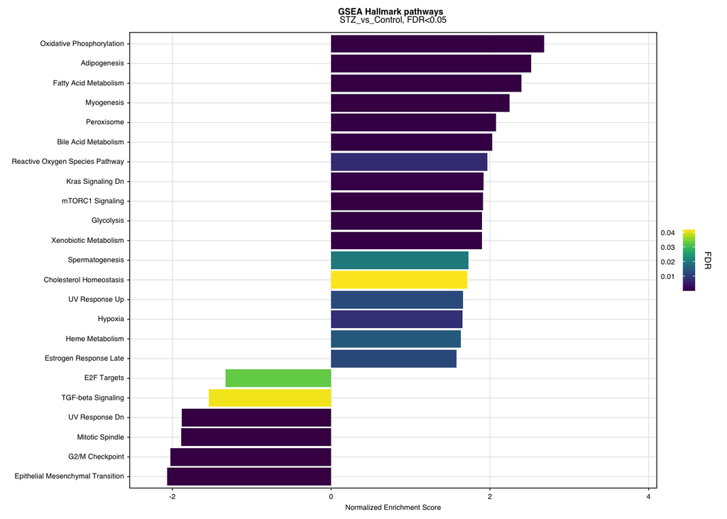

```r
pathway_data %>%
  ggplot(aes(x = ID, y = NES)) +
  geom_bar(stat = "identity", aes(fill = p.adjust), linewidth = 1) +
  # geom_bar(stat = "identity", aes(fill = sign(NES)), linewidth = 1) +
  gg_theme() +
  theme(legend.position = "right") +
  scale_y_continuous(expand = expansion(mult = c(0.1, 0.3))) +
  geom_text(aes(label = rank_of),
    y = (round(
      max(pathway_data[[deparse(substitute(NES))]])
    ) * 1.5),
    hjust = 1,
    size = 5 / ggplot2:::.pt, color = "black"
  ) +
  labs(
    fill = "FDR"
  ) +
  ggplot2::guides(
    fill = guide_colourbar(
      order = 1,
      title.position = "right",
      title.theme = ggtext::element_markdown(size = 6, angle = -90, hjust = 0.5),
      label.position = "left"
    )
  ) +
  coord_flip() +
  scale_fill_viridis(
    option = "D"
    # "magma" (or "A")
    # "inferno" (or "B")
    # "plasma" (or "C")
    # "viridis" (or "D")
    # "cividis" (or "E")
    # "rocket" (or "F")
    # "mako" (or "G")
    # "turbo" (or "H")
  ) +
  # scale_fill_gradient(low = "#1F78B4", high = "#E31A1C") +
  ylab("Normalized Enrichment Score") +
  xlab("") +
  ggtitle(paste0("**GSEA Hallmark pathways** <br> ", contrast1_name, ", FDR<0.05"))
```

save plot

```r
filename <- "Hallmark_barplot_all"

for (file_format in file_formats) {
  ggsave_fixed(
    paste0(
      "../03.figures/",
      filename_prefix,
      "GSEA_",
      filename, ".",
      file_format
    ),
    units = "mm",
    plot_width = 20,
    plot_height = length(pathway_data) * 3,
    width = 90,
    height = length(pathway_data) * 3 + 20
  )
}
```

select pathways

```r
pathway_data %>%
  dplyr::select(ID, NES, pathway_rank) %>%
  arrange(pathway_rank) %>%
  arrange(NES)
```

```
#>                                                                           ID
#> HALLMARK_EPITHELIAL_MESENCHYMAL_TRANSITION Epithelial Mesenchymal Transition
#> HALLMARK_G2M_CHECKPOINT                                      G2/M Checkpoint
#> HALLMARK_MITOTIC_SPINDLE                                     Mitotic Spindle
#> HALLMARK_UV_RESPONSE_DN                                       UV Response Dn
#> HALLMARK_TGF_BETA_SIGNALING                               TGF-beta Signaling
#> HALLMARK_E2F_TARGETS                                             E2F Targets
#> HALLMARK_ESTROGEN_RESPONSE_LATE                       Estrogen Response Late
#> HALLMARK_HEME_METABOLISM                                     Heme Metabolism
#> HALLMARK_HYPOXIA                                                     Hypoxia
#> HALLMARK_UV_RESPONSE_UP                                       UV Response Up
#> HALLMARK_CHOLESTEROL_HOMEOSTASIS                     Cholesterol Homeostasis
#> HALLMARK_SPERMATOGENESIS                                     Spermatogenesis
#> HALLMARK_XENOBIOTIC_METABOLISM                         Xenobiotic Metabolism
#> HALLMARK_GLYCOLYSIS                                               Glycolysis
#> HALLMARK_MTORC1_SIGNALING                                   mTORC1 Signaling
#> HALLMARK_KRAS_SIGNALING_DN                                 Kras Signaling Dn
#> HALLMARK_REACTIVE_OXYGEN_SPECIES_PATHWAY     Reactive Oxygen Species Pathway
#> HALLMARK_BILE_ACID_METABOLISM                           Bile Acid Metabolism
#> HALLMARK_PEROXISOME                                               Peroxisome
#> HALLMARK_MYOGENESIS                                               Myogenesis
#> HALLMARK_FATTY_ACID_METABOLISM                         Fatty Acid Metabolism
#> HALLMARK_ADIPOGENESIS                                           Adipogenesis
#> HALLMARK_OXIDATIVE_PHOSPHORYLATION                 Oxidative Phosphorylation
#>                                                  NES pathway_rank
#> HALLMARK_EPITHELIAL_MESENCHYMAL_TRANSITION -2.068005            6
#> HALLMARK_G2M_CHECKPOINT                    -2.024872            8
#> HALLMARK_MITOTIC_SPINDLE                   -1.890337           14
#> HALLMARK_UV_RESPONSE_DN                    -1.885107           15
#> HALLMARK_TGF_BETA_SIGNALING                -1.539096           22
#> HALLMARK_E2F_TARGETS                       -1.328345           23
#> HALLMARK_ESTROGEN_RESPONSE_LATE             1.582632           21
#> HALLMARK_HEME_METABOLISM                    1.631271           20
#> HALLMARK_HYPOXIA                            1.657280           19
#> HALLMARK_UV_RESPONSE_UP                     1.660879           18
#> HALLMARK_CHOLESTEROL_HOMEOSTASIS            1.714744           17
#> HALLMARK_SPERMATOGENESIS                    1.727132           16
#> HALLMARK_XENOBIOTIC_METABOLISM              1.902205           13
#> HALLMARK_GLYCOLYSIS                         1.902501           12
#> HALLMARK_MTORC1_SIGNALING                   1.909754           11
#> HALLMARK_KRAS_SIGNALING_DN                  1.923303           10
#> HALLMARK_REACTIVE_OXYGEN_SPECIES_PATHWAY    1.967329            9
#> HALLMARK_BILE_ACID_METABOLISM               2.029216            7
#> HALLMARK_PEROXISOME                         2.080088            5
#> HALLMARK_MYOGENESIS                         2.250075            4
#> HALLMARK_FATTY_ACID_METABOLISM              2.395924            3
#> HALLMARK_ADIPOGENESIS                       2.517882            2
#> HALLMARK_OXIDATIVE_PHOSPHORYLATION          2.681489            1
```

Top 10 GSEA Hallmark pathways

```r
selected_pathways <- c(1:10)

pathway_data_selected <- pathway_data %>%
  filter(pathway_rank %in% selected_pathways) %>%
  dplyr::arrange(NES) %>%
  mutate(ID = factor(ID, levels = ID)) # Reorder ID after arranging
```

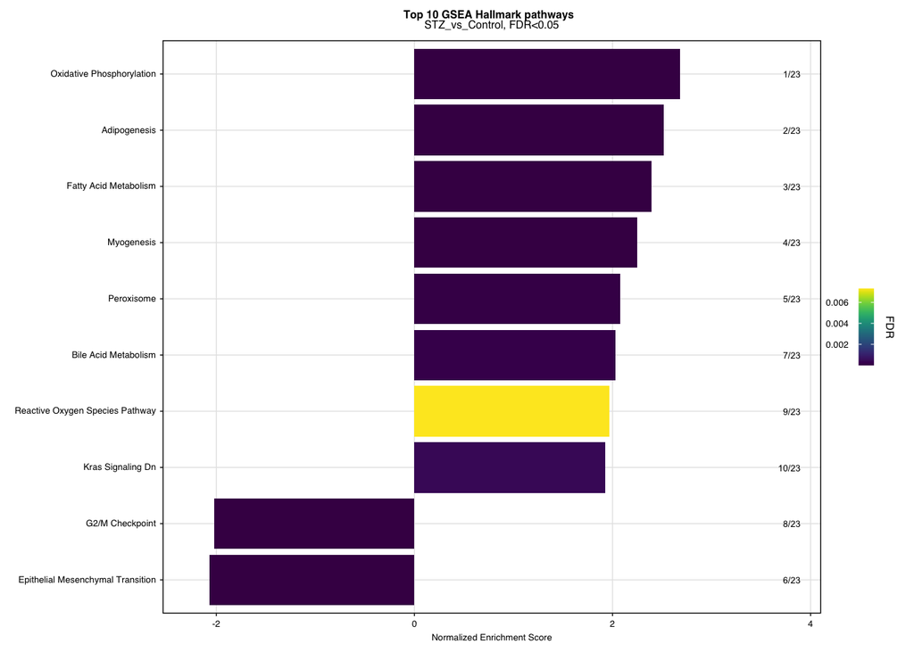

```r
pathway_data_selected %>%
  ggplot(aes(x = ID, y = NES)) +
  geom_bar(stat = "identity", aes(fill = p.adjust), linewidth = 1) +
  # geom_bar(stat = "identity", aes(fill = sign(NES)), linewidth = 1) +
  gg_theme() +
  theme(legend.position = "right") +
  scale_y_continuous(expand = expansion(mult = c(0.1, 0.3))) +
  geom_text(aes(label = rank_of),
    y = (round(
      max(pathway_data_selected[[deparse(substitute(NES))]])
    ) * 1.3),
    hjust = 1,
    size = 5 / ggplot2:::.pt, color = "black"
  ) +
  labs(
    fill = "FDR"
  ) +
  ggplot2::guides(
    fill = guide_colourbar(
      order = 1,
      title.position = "right",
      title.theme = ggtext::element_markdown(size = 6, angle = -90, hjust = 0.5),
      label.position = "left"
    )
  ) +
  coord_flip() +
  scale_fill_viridis(
    option = "D"
    # "magma" (or "A")
    # "inferno" (or "B")
    # "plasma" (or "C")
    # "viridis" (or "D")
    # "cividis" (or "E")
    # "rocket" (or "F")
    # "mako" (or "G")
    # "turbo" (or "H")
  ) +
  # scale_fill_gradient(low = "#1F78B4", high = "#E31A1C") +
  ylab("Normalized Enrichment Score") +
  xlab("") +
  ggtitle(paste0("**Top 10 GSEA Hallmark pathways** <br> ", contrast1_name, ", FDR<0.05"))
```

save plot

```r
filename <- "Hallmark_barplot_selected"

for (file_format in file_formats) {
  ggsave_fixed(
    paste0(
      "../03.figures/",
      filename_prefix,
      "GSEA_",
      filename, ".",
      file_format
    ),
    units = "mm",
    plot_width = 20,
    plot_height = length(pathway_data_selected) * 2,
    width = 75,
    height = length(pathway_data_selected) * 2 + 20
  )
}
```

## 2.2 GSEA plot

```r
# gsea1_full <- readRDS("../01_results/pathways/pathways_GSEA_Hallmark_CF_vs_CL_full.RDS")
gsea1_full <- readRDS(paste0("../02.results/pathways/pathways_GSEA_Hallmark_", contrast1_name, "_full.RDS"))
```

### 2.2.1 visualization

```r
gsea1_full$Description
```

```
#>  [1] "HALLMARK_OXIDATIVE_PHOSPHORYLATION"
#>  [2] "HALLMARK_ADIPOGENESIS"
#>  [3] "HALLMARK_FATTY_ACID_METABOLISM"
#>  [4] "HALLMARK_MYOGENESIS"
#>  [5] "HALLMARK_EPITHELIAL_MESENCHYMAL_TRANSITION"
#>  [6] "HALLMARK_G2M_CHECKPOINT"
#>  [7] "HALLMARK_MITOTIC_SPINDLE"
#>  [8] "HALLMARK_MTORC1_SIGNALING"
#>  [9] "HALLMARK_UV_RESPONSE_DN"
#> [10] "HALLMARK_GLYCOLYSIS"
#> [11] "HALLMARK_PEROXISOME"
#> [12] "HALLMARK_BILE_ACID_METABOLISM"
#> [13] "HALLMARK_XENOBIOTIC_METABOLISM"
#> [14] "HALLMARK_KRAS_SIGNALING_DN"
#> [15] "HALLMARK_REACTIVE_OXYGEN_SPECIES_PATHWAY"
```

[output cut: 35 more lines]

Selecting - [1] “HALLMARK_OXIDATIVE_PHOSPHORYLATION” - [15] “HALLMARK_REACTIVE_OXYGEN_SPECIES_PATHWAY”

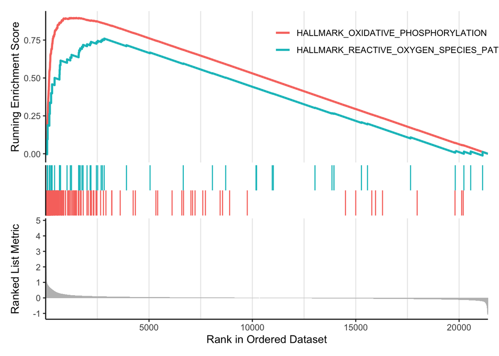

```r
enrichplot::gseaplot2(gsea1_full, geneSetID = c(1,15))
```

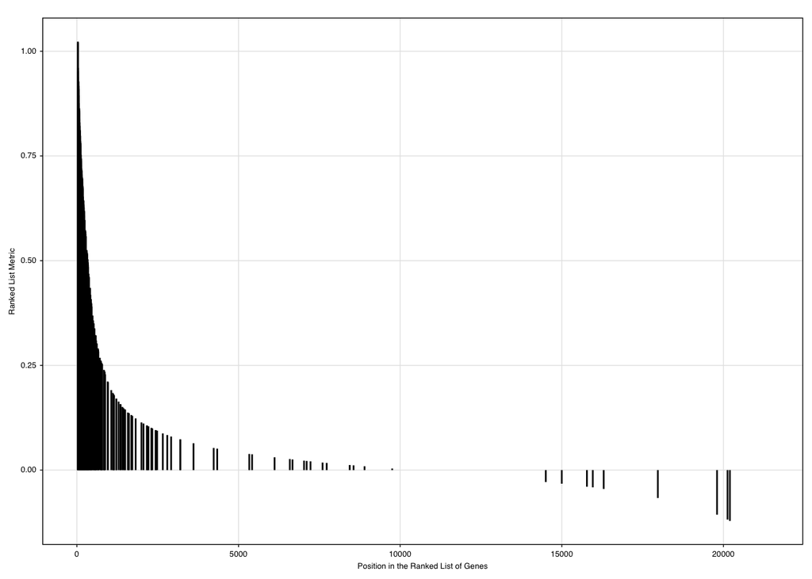

```r
enrichplot::gseaplot(gsea1_full, geneSetID = 1, by = "preranked") + gg_theme()
```

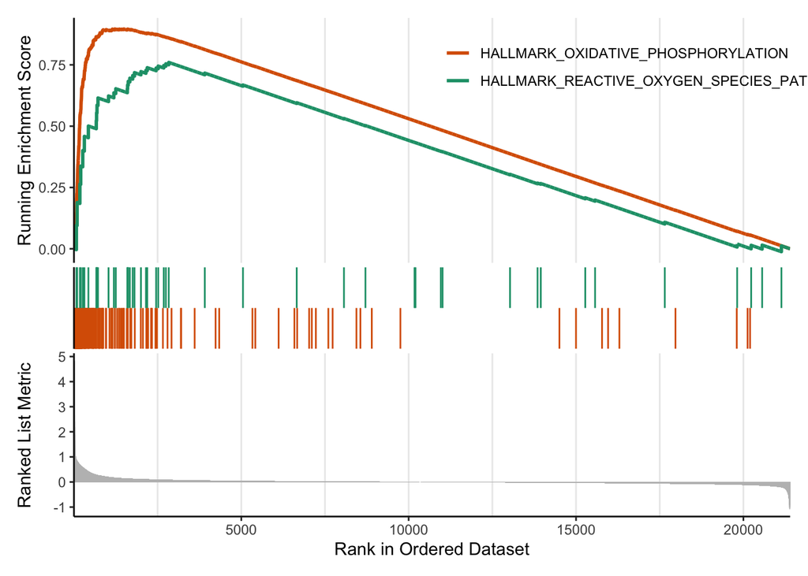

```r
enrichplot::gseaplot2(gsea1_full, geneSetID = c(1,15), subplots = 1:3,
                      color = c("#D95F02", "#1B9E77"))# + gg_theme()
```

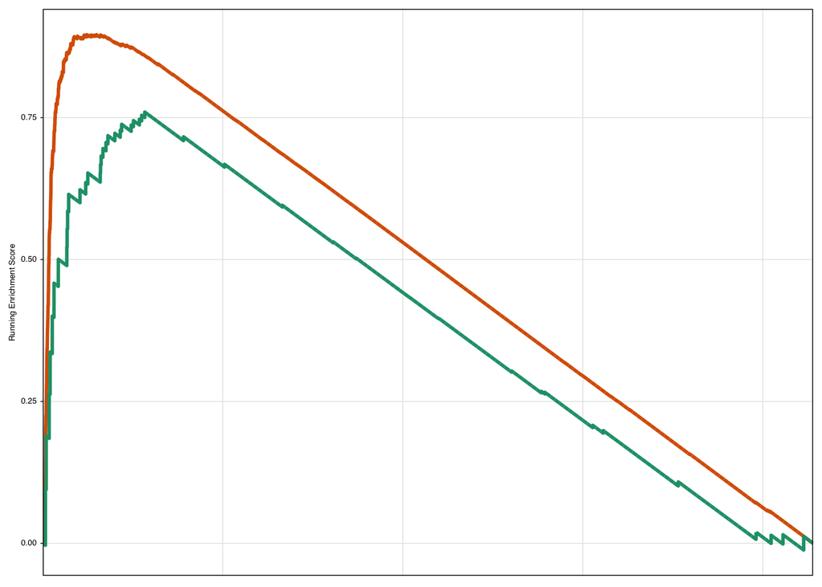

```r
enrichplot::gseaplot2(gsea1_full, geneSetID = c(1,15), subplots = 1,
                      #pvalue_table = TRUE,
                      color = c("#D95F02", "#1B9E77")) +
  gg_theme() +
  theme(
  axis.text.x = element_blank(),  # Remove x-axis text
  axis.ticks.x = element_blank()   # Remove x-axis ticks
  )
```

save plot

```r
filename <- paste0("GSEAplot_Oxphox_ROS_line")

for (file_format in file_formats) {
  ggsave_fixed(
    paste0(
      "../03.figures/",
      filename_prefix,
      filename, ".",
      file_format
    ),
    units = "mm",
    plot_width = 40,
    plot_height = 15,
    width = 100,
    height = 60
  )
}
```

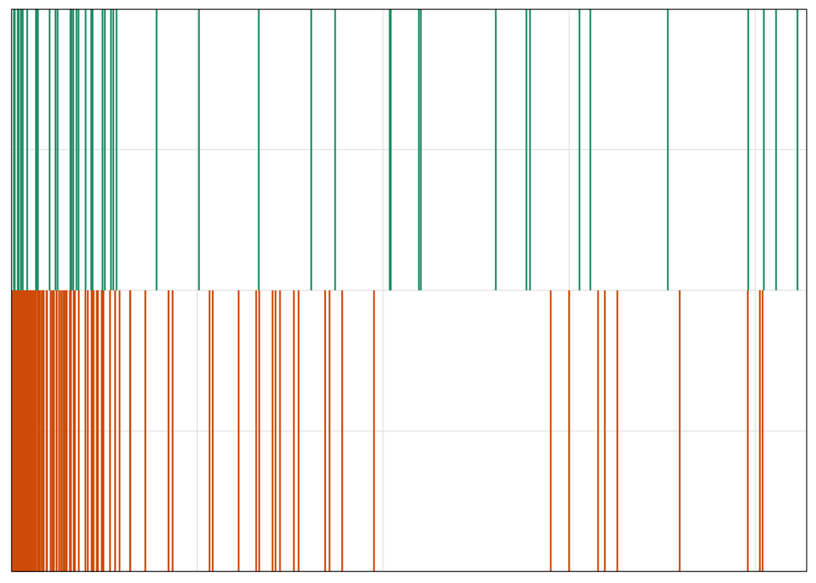

```r
enrichplot::gseaplot2(gsea1_full,
  geneSetID = c(1, 15), subplots = 2,
  color = c("#D95F02", "#1B9E77")
) +
  gg_theme() +
  theme(
    axis.text.x = element_blank(), # Remove x-axis text
    axis.ticks.x = element_blank(), # Remove x-axis ticks
    axis.text.y = element_blank(), # Remove y-axis text
    axis.ticks.y = element_blank() # Remove y-axis ticks
  )
```

save plot

```r
filename <- paste0("GSEAplot_Oxphox_ROS_genes")

for (file_format in file_formats) {
  ggsave_fixed(
    paste0(
      "../03.figures/",
      filename_prefix,
      filename, ".",
      file_format
    ),
    units = "mm",
    plot_width = 40,
    plot_height = 5,
    width = 45,
    height = 10
  )
}
```

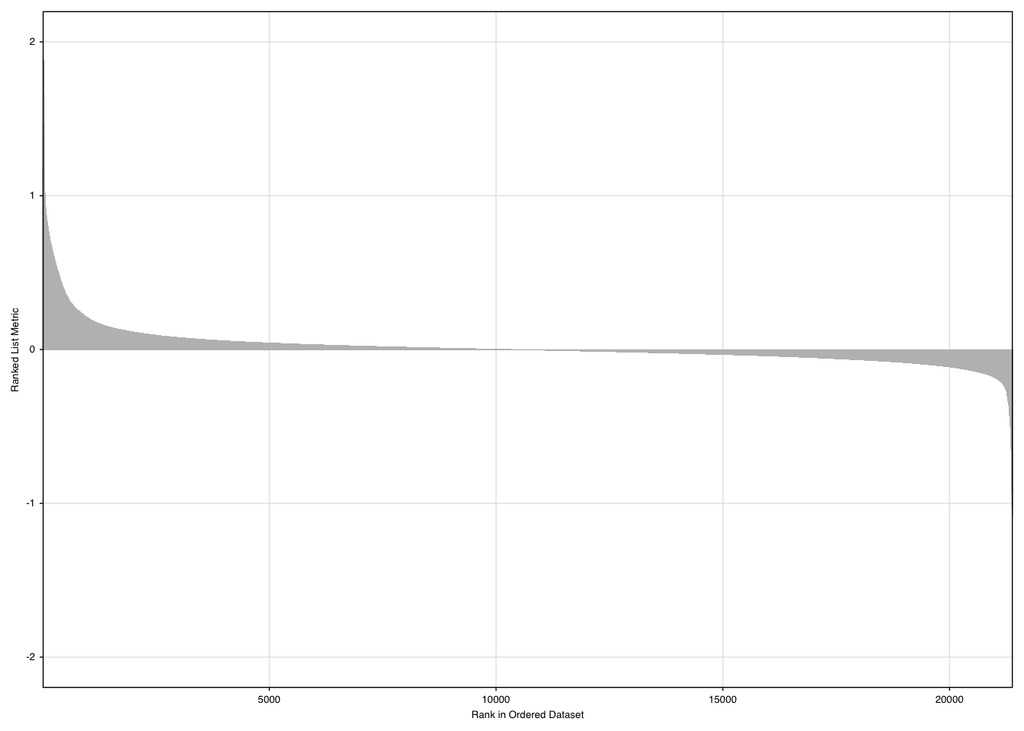

```r
enrichplot::gseaplot2(gsea1_full, geneSetID = c(1,15), subplots = 3,
                      color = c("#D95F02", "#1B9E77")) +
  gg_theme() +
  scale_y_continuous(
    limits = c(-2,2),
    breaks = seq(-2, 2, by = 1))  # Sets y-axis breaks every 10 units
```

save plot

```r
filename <- paste0("GSEAplot_Oxphox_ROS_rank")

for (file_format in file_formats) {
  ggsave_fixed(
    paste0(
      "../03.figures/",
      filename_prefix,
      filename, ".",
      file_format
    ),
    units = "mm",
    plot_width = 40,
    plot_height = 10,
    width = 100,
    height = 60
  )
}
```

# 3 ORA

# 4 Contrasts

```r
group1 <- levels(metadata$Group)[2]
# group2 <- levels(metadata$group)[3]
group_ref <- levels(metadata$Group)[1]


#contrast1 <- paste0(group,"_vs_",group_ref)
contrast1_name <- paste0(group1,"_vs_",group_ref)
contrast1_name
```

```
#> [1] "STZ_vs_Control"
```

```r
# gsea1_full <- readRDS("../01_results/pathways/pathways_GSEA_Hallmark_CF_vs_CL_full.RDS")
pathways_ORA <- readRDS(paste0("../02.results/pathways/pathways_ORA.RDS"))
# contrast2 <- readRDS(paste0("../02.results/pathways/pathways_GSEA_Hallmark_", group2,"_vs_",group_ref,".RDS"))
```

```r
pathways_ORA <- pathways_ORA %>%
  #full_join(contrast1) %>%
  #full_join(contrast3) %>%
  #mutate(ID = stringr::str_replace(ID, "HALLMARK_", "")) %>%
  mutate(ID = stringr::str_replace_all(ID, "_", " ")) %>%
  mutate(ID = tools::toTitleCase(tolower(ID))) %>%
  mutate(ID = str_replace_all(ID, pattern = replacements)) %>%
  mutate(ID = stringr::str_trim(ID))


unique(pathways_ORA$comparison)
```

```
#> [1] "STZ_vs_Control"
```

```r
pathways_ORA <- pathways_ORA %>%
  mutate(comparison = factor(comparison, levels = c(
    contrast1_name
  )))
levels(pathways_ORA$comparison)
```

```
#> [1] "STZ_vs_Control"
```

```r
colnames(pathways_ORA)
```

```
#>  [1] "ID"             "Description"    "GeneRatio"      "BgRatio"
#>  [5] "RichFactor"     "FoldEnrichment" "zScore"         "pvalue"
#>  [9] "p.adjust"       "qvalue"         "geneID"         "Count"
#> [13] "group"          "direction"      "comparison"     "GeneRatio2"
#> [17] "collection"
```

## 4.1 Data tyding

```r
colnames(pathways_ORA)
```

```
#>  [1] "ID"             "Description"    "GeneRatio"      "BgRatio"
#>  [5] "RichFactor"     "FoldEnrichment" "zScore"         "pvalue"
#>  [9] "p.adjust"       "qvalue"         "geneID"         "Count"
#> [13] "group"          "direction"      "comparison"     "GeneRatio2"
#> [17] "collection"
```

```r
unique(pathways_ORA$direction)
```

```
#> [1] "Increased" "Decreased"
```

```r
unique(pathways_ORA$collection)
```

```
#> [1] "Hallmark"     "GOBP"         "MitoPathways"
```

```r
pathways_ORA <- pathways_ORA %>%
  mutate(log10_padj = -log10(p.adjust)) %>%
    mutate(direction = factor(direction, levels = c(
           "Increased",
           "Decreased"
           )
           )
         )
colnames(pathways_ORA)
```

```
#>  [1] "ID"             "Description"    "GeneRatio"      "BgRatio"
#>  [5] "RichFactor"     "FoldEnrichment" "zScore"         "pvalue"
#>  [9] "p.adjust"       "qvalue"         "geneID"         "Count"
#> [13] "group"          "direction"      "comparison"     "GeneRatio2"
#> [17] "collection"     "log10_padj"
```

```r
selected_collection <- "GOBP"
```

```r
combined <- pathways_ORA %>%
  arrange(group, p.adjust) %>%
  filter(p.adjust < 0.05,
         collection %in% selected_collection) %>%
  #dplyr::filter(direction == "Increased") %>%
  group_by(group) %>%
  slice_head(n = 5)
```

Both

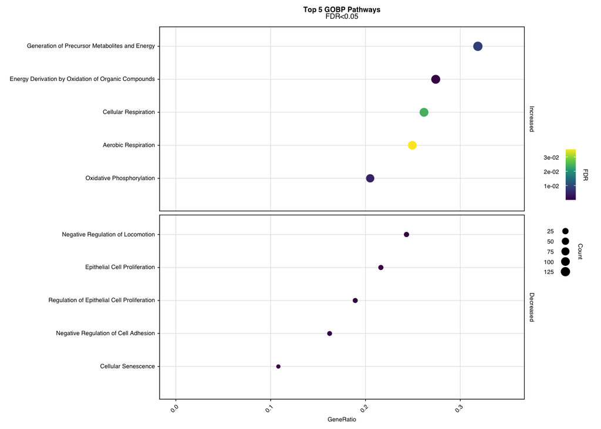

```r
ggplot(combined, aes(
    x = GeneRatio2,
    y = fct_reorder(ID, GeneRatio2),
    colour = rev(p.adjust),
    size = Count,
  )) +
  geom_point() +
  # scale_x_discrete(position = "top") +
  gg_theme() +
  theme(
    legend.position = "right",
    panel.spacing.y = unit(1, "mm"),
    strip.text = element_text(face = "plain"),
    axis.text.x = ggtext::element_markdown(size = 5, colour = "black", angle = 45, hjust = 1)
  ) +
  xlab("GeneRatio") +
  ylab("") +
  scale_color_viridis_c(
    option = "viridis",
    labels = scales::scientific_format(scale = 1, digits = 2),
    #breaks = c(1e-05, 1e-04, 1e-03, 1e-02),
    breaks = scales::pretty_breaks(n = 5),  # Setting number of breaks
    # limits = c(-2, 2),
    #oob = scales::squish
  ) +
  labs(
    colour = "FDR",
    size = "Count"
  ) +
  ggplot2::guides(
    colour = guide_colourbar(
      order = 1,
      title.position = "right",
      title.theme = ggtext::element_markdown(size = 5, angle = -90, hjust = 0.5),
      label.position = "left"
    ),
    size = guide_legend(
      order = 2,
      title.position = "right",
      title.theme = ggtext::element_markdown(size = 5, angle = -90, hjust = 0.5),
      label.position = "left"
    )
  ) +
  scale_size(range = c(1, 3), ) +
  expand_limits(
    x = c(0, max(combined$GeneRatio2) * 1.1),
    y = c(0, max(as.numeric(as.character(combined$ID))) * 1.1)
  ) +
  facet_grid(rows = vars(direction), scales = "free_y", space = "free_y") +
  #facet_grid(group ~ ., scales = "free_y") +
  ggtitle(paste0("**Top 5 ", selected_collection, " Pathways**<br> FDR<0.05"))
```

save plot

```r
filename <- paste0("ORA_",selected_collection,"_both")

for (file_format in file_formats) {
  ggsave_fixed(
    paste0(
      "../03.figures/",
      filename_prefix,
      filename, ".",
      file_format
    ),
    units = "mm",
    plot_width = 15,
    plot_height = c(20,12),
    width = 100,
    height = 60
  )
}
```

```r
selected_collection <- "MitoPathways"
```

```r
combined <- pathways_ORA %>%
  arrange(group, p.adjust) %>%
  filter(p.adjust < 0.05,
         collection %in% selected_collection) %>%
  #dplyr::filter(direction == "Increased") %>%
  group_by(group)

combined$ID
```

```
#>  [1] "OXPHOS Subunits"          "OXPHOS"
#>  [3] "CI Subunits"              "Complex I"
#>  [5] "TCA Cycle"                "CV Subunits"
#>  [7] "Complex v"                "Carbohydrate Metabolism"
#>  [9] "CIV Subunits"             "Fe-S-containing Proteins"
#> [11] "Complex III"              "Cristae Formation"
#> [13] "Pyruvate Metabolism"      "Complex IV"
```

```r
selected_pathways <- c(2,4,5,8,7,10,14,11,12,13)

combined_filtered <- combined[selected_pathways,]
```

plot

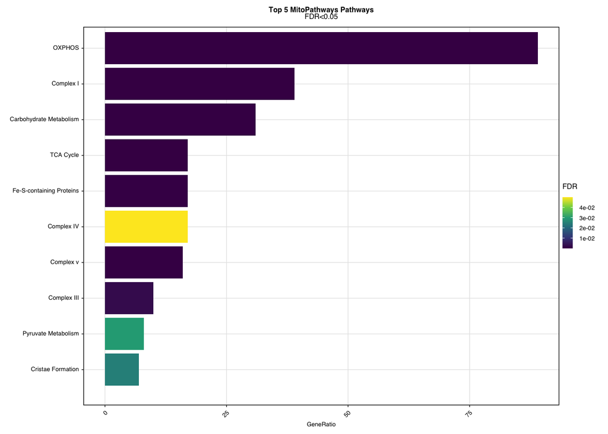

```r
ggplot(combined_filtered, aes(
    x = Count,
    y = fct_reorder(ID, GeneRatio2),
    fill = p.adjust
  )) +
  # geom_point() +
  geom_bar(stat = "identity") +
  # scale_x_discrete(position = "top") +
  gg_theme() +
  theme(
    legend.position = "right",
    panel.spacing.y = unit(1, "mm"),
    strip.text = element_text(face = "plain"),
    axis.text.x = ggtext::element_markdown(size = 5, colour = "black", angle = 45, hjust = 1)
  ) +
  xlab("GeneRatio") +
  ylab("") +
  scale_fill_viridis_c(
    option = "viridis",
    labels = scales::scientific_format(scale = 1, digits = 2),
    #breaks = c(1e-05, 1e-04, 1e-03, 1e-02),
    breaks = scales::pretty_breaks(n = 5),  # Setting number of breaks
    # limits = c(-2, 2),
    #oob = scales::squish
  ) +
  labs(
    fill = "FDR",
    #size = "Count"
  ) +
  ggplot2::guides(
    colour = guide_colourbar(
      order = 1,
      title.position = "right",
      title.theme = ggtext::element_markdown(size = 5, angle = -90, hjust = 0.5),
      label.position = "left"
    ),
    size = guide_legend(
      order = 2,
      title.position = "right",
      title.theme = ggtext::element_markdown(size = 5, angle = -90, hjust = 0.5),
      label.position = "left"
    )
  ) +
  scale_size(range = c(1, 3), ) +
  expand_limits(
    x = c(0, max(combined$GeneRatio2) * 1.1),
    y = c(0, max(as.numeric(as.character(combined$ID))) * 1.1)
  ) +
  #facet_grid(rows = vars(direction), scales = "free_y", space = "free_y") +
  #facet_grid(group ~ ., scales = "free_y") +
  ggtitle(paste0("**Top 5 ", selected_collection, " Pathways**<br> FDR<0.05"))
```

save plot

```r
filename <- paste0("ORA_",selected_collection)

for (file_format in file_formats) {
  ggsave_fixed(
    paste0(
      "../03.figures/",
      filename_prefix,
      filename, ".",
      file_format
    ),
    units = "mm",
    plot_width = 15,
    plot_height = 30,
    width = 60,
    height = 50
  )
}
```

# 6 References

- Subramanian A, Tamayo P, Mootha VK, Mukherjee S, Ebert BL, Gillette MA, Paulovich A, Pomeroy SL, Golub TR, Lander ES, Mesirov JP. 2005. Gene set enrichment analysis: A knowledge-based approach for interpreting genome-wide expression profiles. Proceedings of the National Academy of Sciences 102:15545–15550. [Link](https://www.pnas.org/doi/10.1073/pnas.0506580102)
- Mootha VK, Lindgren CM, Eriksson K-F, Subramanian A, Sihag S, Lehar J, Puigserver P, Carlsson E, Ridderstråle M, Laurila E, Houstis N, Daly MJ, Patterson N, Mesirov JP, Golub TR, Tamayo P, Spiegelman B, Lander ES, Hirschhorn JN, Altshuler D, Groop LC. 2003. PGC-1α-responsive genes involved in oxidative phosphorylation are coordinately downregulated in human diabetes. Nat Genet 34:267–273. [Link](https://www.nature.com/articles/ng1180)
- T Wu, E Hu, S Xu, M Chen, P Guo, Z Dai, T Feng, L Zhou, W Tang, L Zhan, X Fu, S Liu, X Bo, and G Yu. clusterProfiler 4.0: A universal enrichment tool for interpreting omics data. The Innovation. 2021, 2(3):100141

[Introduction to msigdbr](https://igordot.github.io/msigdbr/articles/msigdbr-intro.html)